# slides_regression1 slides

## DSCI 100 - Introduction to Data Science

### Lecture 8 - Regression with k-nearest neighbours

[figure not shown]

Source: Artwork by @allison_horst

## Housekeeping

- The second class meeting of this week is a **lecture** period.

### Regression prediction problem

What if we want to predict a quantitative value instead of a class label?

[figure not shown]

E.g.: predict the price of a 2000 square foot home (from this reduced dataset)

[figure not shown]

### K nearest neighbours regression

As in k-nn classification, we find the $k$-nearest neighbours (here $k=5$) in terms of the predictors

[figure not shown]

### K nearest neighbours regression

Then we average the values for the $k$-nearest neighbours, and use that as the prediction:

[figure not shown]

### K nearest neighbours regression

If we do that for a range of house sizes, we can draw the curve of predictions:

[figure not shown]

### Regression prediction problem

We still have to answer these two questions:

1. Is our model any good?
2. How do we choose `k`?

The same general strategy as in classification works here!

[figure not shown]

### 1. Is our model any good?

**The blue line** depicts our predictions from k-nn regression.

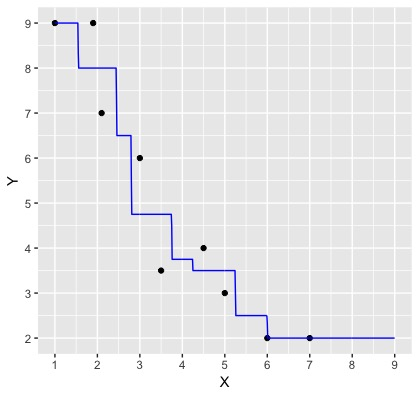

### 1. Is our model any good?

**The blue line** depicts our predictions from k-nn regression. **The red lines** depict the error in our predictions, i.e., the difference between the $i^\text{th}$ test data response and our prediction $\hat{y}_i$:

[figure not shown]

### 1. Is our model any good?

We (roughly) add up these errors to evaluate our regression model

- Not out of 1, but instead in units of the target variable (bit harder to interpret)

[output not shown]

### RMSE vs RMSPE

- *Root Mean Squared Error (RMSE)*: The same formula except on *the data used to train the model*
  - this indicates how well our model can fit our data
- *Root Mean Squared Prediction Error (RMSPE)*: predicting on *unseen data.*
  - this indicates how well our model *generalizes* to future data

**No standard terminology.**

### Final model from k-nn regression

For this model, RMSPE is 91,620.4. How can we interpret this?

[figure not shown]

### 2. How do we choose k?

Roughly the same as before!

1. Cross validation:
   - Split data into $C$ folds
   - Train
   - Evaluate model
   - Pick k that gives the lowest RMSPE on validation set
2. Train model on whole training dataset (not split into folds)
3. Evaluate how good the predictions are using the test data

### How does $k$ affect k-nn regression?

[figure not shown]

### Discussion: Which of the following is overfitting? Underfitting?

[figure not shown]

## Worksheet time - go for it!